# Final Project

Final Project Presentation

Xutao Liu

### League of Legends

League of Legends is a fast-paced, competitive online game that blends the speed and intensity of an RTS with RPG elements, also known MOBA, or Multiplayer online battle arena. In which two teams of powerful champions, each with a unique design and playstyle, battle head-to-head across multiple battlefields and game modes (5 vs. 5 competitive PC game).

It is one of - if not the most - popular game currently around. LoL has a professional league. The top prize for the best team is over five million dollars and the average player makes a six-figure income This is the dataset for Competitive matches of League of Legends from 2015 to 2018. [here’s the link](https://na.leagueoflegends.com/en/game-info/get-started/what-is-lol/)

[figure not shown]

- The guiding question/ motivation for your analysis

I wants to know whcih teams have won the Championship during the years.

*** Does a team who play more games played in the league have a greater chance to become/enter World Championship and win ?

- An obstacle that you encountered, and how you resolved it

Trying to load the data from kaggle(website) into R failed, so I downloaed file and import locally

- The key insights, conclusions, or takeaway with respect to your guiding question/motivation based on your work

Base on the Number of games different League played Graph, we can see that LCK (South Korea) have played most competitive matches out of all other different regions with total of 1445, and out of that, SKT played 403 games, and SSG played 322 games. No wonder they are the best team in the world.

[Wikipedia](https://en.wikipedia.org/wiki/League_of_Legends_World_Championship#Season_8) [KaggleData](https://www.kaggle.com/chuckephron/leagueoflegends#matchinfo.csv)

```r
# clean up workspace environment
rm(list = ls())

# all packages used for the assignment
library(mosaic)
library(tidyverse)
library(mosaicData)
library(DataComputing)
library(rvest)
```

##### Loading data from Wikipedia into R is easy.

It have the teams that have won the championship and the region that won the championship

```r
page <- ("https://en.wikipedia.org/wiki/League_of_Legends_World_Championship#Overview")
topFour <- page %>%
  read_html() %>%
  html_nodes(css = "table") %>%
  html_table(fill = TRUE)

head(topFour[[3]])
```

|  | Team | Titles | Runner-up | 3rd-4th |
| --- | --- | --- | --- | --- |
| 1 | SK Telecom T1 | 3 (2013, 2015, 2016) | 1 (2017) | 1 (2019) |
| 2 | Samsung Galaxy | 2 (2014, 2017) | 1 (2016) | 1 (2014) |
| 3 | Fnatic | 1 (2011) | 1 (2018) | 2 (2013, 2015) |
| 4 | Invictus Gaming | 1 (2018) |  | 1 (2019) |
| 5 | Taipei Assassins | 1 (2012) |  |  |
| 6 | FunPlus Phoenix | 1 (2019) |  |  |

```r
head(topFour[[4]])
```

|  | Region | Titles | Runner-up | 3rd-4th |
| --- | --- | --- | --- | --- |
| 1 | South Korea (LCK) | 5 (2013, 2014, 2015, 2016, 2017) | 4 (2012 2015 2016 2017) | 4 (2013, 2014, 2016, 2019) |
| 2 | China (LPL) | 2 (2018, 2019) | 2 (2013, 2014) | 4 (2014, 2017*, 2019) |
| 3 | Europe (LEC) | 1 (2011) | 3 (2011, 2018, 2019) | 6 (2012, 2013, 2015*, 2016, 2018) |
| 4 | TW/HK/MO (LMS) | 1 (2012) |  |  |
| 5 | North America (LCS) |  |  | 3 (2011*, 2018) |
| 6 | CIS (LCL) |  |  | 1 (2012[A]) |

##### Trying to load Kaggle data that’s online but ending in csv into R, but failed.

```r
pageK <- ("https://www.kaggle.com/chuckephron/leagueoflegends#matchinfo.csv")
tableListK <- pageK %>%
  read_html() %>%
  html_nodes(css = "table") %>%
  html_table(fill = TRUE)

head(tableListK)
```

```
list()
```

##### Loading csv file locally

```r
matchData <- read.csv('/Users/jack/Desktop/STAT 184/matchinfo.csv')

head(matchData)
```

|  | League | Year | Season | Type | blueTeamTag | bResult | rResult | redTeamTag | gamelength | blueTop | blueTopChamp | blueJungle | blueJungleChamp | blueMiddle | blueMiddleChamp | blueADC | blueADCChamp | blueSupport | blueSupportChamp | redTop | redTopChamp | redJungle | redJungleChamp | redMiddle | redMiddleChamp | redADC | redADCChamp | redSupport | redSupportChamp | … |
| --- | --- | --- | --- | --- | --- | --- | --- | --- | --- | --- | --- | --- | --- | --- | --- | --- | --- | --- | --- | --- | --- | --- | --- | --- | --- | --- | --- | --- | --- | --- |
| 1 | NALCS | 2015 | Spring | Season | TSM | 1 | 0 | C9 | 40 | Dyrus | Irelia | Santorin | RekSai | Bjergsen | Ahri | WildTurtle | Jinx | Lustboy | Janna | Balls | Gnar | Meteos | Elise | Hai | Fizz | Sneaky | Sivir | LemonNation | Thresh | … |
| 2 | NALCS | 2015 | Spring | Season | CST | 0 | 1 | DIG | 38 | Cris | Gnar | Impaler | Rengar | Jesiz | Ahri | Mash | Caitlyn | Sheep | Leona | Gamsu | Irelia | Crumbzz | JarvanIV | Shiphtur | Azir | CoreJJ | Corki | KiWiKiD | Annie | … |
| 3 | NALCS | 2015 | Spring | Season | WFX | 1 | 0 | GV | 40 | Flaresz | Renekton | ShorterACE | Rengar | Pobelter | Fizz | Altec | Sivir | Gleeb | Annie | Hauntzer | Sion | Saintvicious | LeeSin | Keane | Azir | Cop | Corki | BunnyFuFuu | Janna | … |
| 4 | NALCS | 2015 | Spring | Season | TIP | 0 | 1 | TL | 41 | Rhux | Irelia | Rush | JarvanIV | XiaoWeiXiao | Leblanc | Apollo | Sivir | Adrian | Thresh | Quas | Gnar | IWDominate | Nunu | Fenix | Lulu | KEITH | KogMaw | Xpecial | Janna | … |
| 5 | NALCS | 2015 | Spring | Season | CLG | 1 | 0 | T8 | 35 | Benny | Gnar | Xmithie | JarvanIV | Link | Lissandra | Doublelift | Tristana | aphromoo | Janna | CaliTrlolz8 | Sion | Porpoise8 | RekSai | Slooshi8 | Lulu | Maplestreet8 | Corki | Dodo8 | Annie | … |
| 6 | NALCS | 2015 | Spring | Season | DIG | 0 | 1 | TIP | 24 | Gamsu | Kassadin | Crumbzz | Rengar | Shiphtur | Leblanc | CoreJJ | Sivir | KiWiKiD | Annie | Rhux | Gnar | Rush | JarvanIV | XiaoWeiXiao | Lulu | Apollo | Corki | Adrian | Thresh | … |

##### Find out the number of games played by each league

```r
numLeague <-
  matchData %>%
  group_by(League) %>%
  summarise(count = n())
numLeague
```

| League | count |
| --- | --- |
| CBLoL | 301 |
| CLS | 175 |
| EULCS | 1099 |
| IEM | 138 |
| LCK | 1445 |
| LCL | 281 |
| LJL | 258 |
| LLN | 242 |
| LMS | 778 |
| MSI | 111 |

[output cut: 5 more lines]

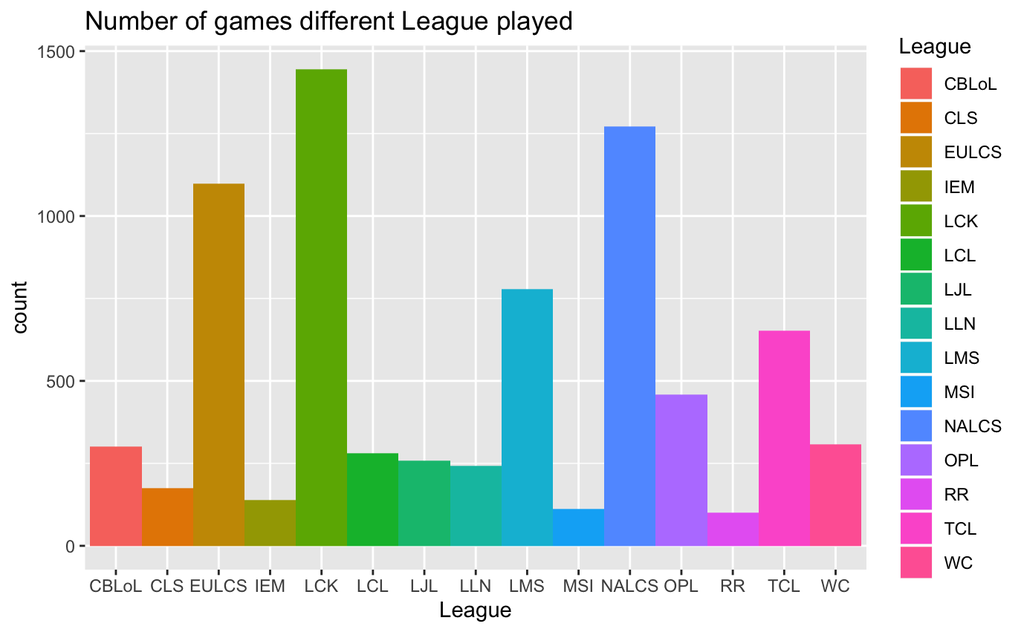

```r
ggplot(data=numLeague,aes(x=League,y=count ,fill=League))+
  geom_bar(stat='identity',position='stack', width=1)+
  ggtitle("Number of games different League played")
```

##### By looking at the graph, we can see that LCK (South Korea) have played most competitive matches out of all other different regions

```r
numType <-
  matchData %>%
  group_by(Type) %>%
  summarise(count = n())
numType
```

[output not shown]

```r
LCK <-
  matchData %>%
  filter(League == "LCK")
head (LCK)
```

|  | League | Year | Season | Type | blueTeamTag | bResult | rResult | redTeamTag | gamelength | blueTop | blueTopChamp | blueJungle | blueJungleChamp | blueMiddle | blueMiddleChamp | blueADC | blueADCChamp | blueSupport | blueSupportChamp | redTop | redTopChamp | redJungle | redJungleChamp | redMiddle | redMiddleChamp | redADC | redADCChamp | redSupport | redSupportChamp | … |
| --- | --- | --- | --- | --- | --- | --- | --- | --- | --- | --- | --- | --- | --- | --- | --- | --- | --- | --- | --- | --- | --- | --- | --- | --- | --- | --- | --- | --- | --- | --- |
| 1 | LCK | 2015 | Spring | Playoffs | CJE | 1 | 0 | JAG | 27 | Shy | Hecarim | Ambition | Nunu | Coco | Cassiopeia | Space | KogMaw | MadLife | Morgana | TrAce | Shyvana | Chaser | Sejuani | GBM | Lulu | Pilot | Jinx | Chei | Thresh | … |
| 2 | LCK | 2015 | Spring | Playoffs | JAG | 0 | 1 | CJE | 33 | TrAce | Shyvana | Chaser | Sejuani | GBM | Cassiopeia | Pilot | Jinx | Chei | Morgana | Shy | Hecarim | Ambition | Gragas | Coco | Ziggs | Space | Corki | MadLife | Nautilus | … |
| 3 | LCK | 2015 | Spring | Playoffs | CJE | 1 | 0 | JAG | 35 | Shy | Shyvana | Ambition | Gragas | Coco | Ziggs | Space | Urgot | MadLife | Thresh | TrAce | Lulu | Chaser | Sejuani | GBM | Cassiopeia | Cpt Jack | Sivir | Chei | Nautilus | … |
| 4 | LCK | 2015 | Spring | Playoffs | CJE | 1 | 0 | SKT | 44 | Shy | Shyvana | Ambition | Nunu | Coco | Azir | Space | Urgot | MadLife | Nautilus | MaRin | Hecarim | Tom | Gragas | Easyhoon | Vladimir | Bang | Sivir | Wolf | Janna | … |
| 5 | LCK | 2015 | Spring | Playoffs | SKT | 0 | 1 | CJE | 32 | MaRin | Gnar | Tom | Nunu | Faker | Xerath | Bang | Urgot | Wolf | Alistar | Shy | Hecarim | Ambition | Gragas | Coco | Vladimir | Space | Sivir | MadLife | Nautilus | … |
| 6 | LCK | 2015 | Spring | Playoffs | CJE | 0 | 1 | SKT | 31 | Shy | Hecarim | Ambition | Nunu | Coco | Ryze | Space | Jinx | MadLife | Nautilus | MaRin | Maokai | Bengi | RekSai | Faker | Lulu | Bang | Sivir | Wolf | Thresh | … |

##### All the matches that SKT (SK Telecom T1) have played

```r
BlueSKT <-
  matchData %>%
  filter( grepl(pattern = "SKT", blueTeamTag))
BlueSKT
```

| League | Year | Season | Type | blueTeamTag | bResult | rResult | redTeamTag | gamelength | blueTop | blueTopChamp | blueJungle | blueJungleChamp | blueMiddle | blueMiddleChamp | blueADC | blueADCChamp | blueSupport | blueSupportChamp | redTop | redTopChamp | redJungle | redJungleChamp | redMiddle | redMiddleChamp | redADC | redADCChamp | redSupport | redSupportChamp | Address |
| --- | --- | --- | --- | --- | --- | --- | --- | --- | --- | --- | --- | --- | --- | --- | --- | --- | --- | --- | --- | --- | --- | --- | --- | --- | --- | --- | --- | --- | --- |
| LCK | 2015 | Spring | Playoffs | SKT | 0 | 1 | CJE | 32 | MaRin | Gnar | Tom | Nunu | Faker | Xerath | Bang | Urgot | Wolf | Alistar | Shy | Hecarim | Ambition | Gragas | Coco | Vladimir | Space | Sivir | MadLife | Nautilus | http://matchhistory.na.leagueoflegends.com/en/#match-details/TRKR1/580105?gameHash=156fcf3fa2776e3f |
| LCK | 2015 | Spring | Playoffs | SKT | 1 | 0 | CJE | 72 | MaRin | Maokai | Bengi | RekSai | Faker | Lulu | Bang | Lucian | Wolf | Annie | Shy | Gnar | Ambition | Gragas | Coco | Ziggs | Space | Sivir | MadLife | Thresh | http://matchhistory.na.leagueoflegends.com/en/#match-details/TRKR1/580109?gameHash=b817640f2c56dc89 |
| LCK | 2015 | Spring | Playoffs | SKT | 1 | 0 | CJE | 35 | MaRin | Maokai | Bengi | RekSai | Faker | Leblanc | Bang | Kalista | Wolf | Thresh | Shy | Shyvana | Ambition | Gragas | Coco | Azir | Space | Urgot | MadLife | Nautilus | http://matchhistory.na.leagueoflegends.com/en/#match-details/TRKR1/580110?gameHash=394ba5e889b3e4b5 |
| LCK | 2015 | Spring | Playoffs | SKT | 1 | 0 | GET | 31 | MaRin | Gnar | Tom | Nunu | Easyhoon | Azir | Bang | Corki | Wolf | Alistar | Smeb | Irelia | LEE | Sejuani | Kuro | Cassiopeia | PraY | Sivir | GorillA | Thresh | http://matchhistory.na.leagueoflegends.com/en/#match-details/TRKR1/590153?gameHash=78a0a4658cb1e9c9 |
| LCK | 2015 | Spring | Season | SKT | 1 | 0 | NJE | 36 | MaRin | Maokai | Bengi | LeeSin | Easyhoon | Xerath | Bang | Corki | Wolf | Janna | Duke | DrMundo | Watch | JarvanIV | Ggoong | Jayce | Ohq | Tristana | Cain | Nami | http://matchhistory.na.leagueoflegends.com/en/#match-details/TRKR1/450030?gameHash=92f4bf24e0a8cb58 |
| LCK | 2015 | Spring | Season | SKT | 0 | 1 | CJE | 46 | MaRin | Gnar | Bengi | LeeSin | Easyhoon | Xerath | Bang | Sivir | Wolf | Annie | Shy | DrMundo | Ambition | JarvanIV | Coco | Jayce | Space | Corki | MadLife | Braum | http://matchhistory.na.leagueoflegends.com/en/#match-details/TRKR1/450120?gameHash=115553e3b5040446 |
| LCK | 2015 | Spring | Season | SKT | 1 | 0 | kt | 40 | MaRin | Gnar | Bengi | JarvanIV | Faker | Syndra | Bang | Corki | Wolf | Janna | Ssumday | Lissandra | Score | LeeSin | Nagne | Leblanc | Arrow | Sivir | hachani | Lulu | http://matchhistory.na.leagueoflegends.com/en/#match-details/TRKR1/450212?gameHash=4b5a48e5e6fbd890 |
| LCK | 2015 | Spring | Season | SKT | 1 | 0 | IM | 30 | MaRin | Rumble | Bengi | JarvanIV | Faker | Ezreal | Bang | Sivir | Wolf | Annie | Lil4c | Lissandra | Wisdom | LeeSin | Frozen | Ahri | SONSTAR | Corki | TusiN | Thresh | http://matchhistory.na.leagueoflegends.com/en/#match-details/TRKR1/440316?gameHash=d9e3bce405fb297f |
| LCK | 2015 | Spring | Season | SKT | 0 | 1 | JAG | 47 | MaRin | Renekton | Bengi | LeeSin | Faker | Xerath | Bang | Sivir | Piccaboo | Braum | TrAce | Gnar | Chaser | JarvanIV | GBM | Ahri | Pilot | Corki | Chei | Janna | http://matchhistory.na.leagueoflegends.com/en/#match-details/TRKR1/440499?gameHash=4508a7660c42b6d8 |
| LCK | 2015 | Spring | Season | SKT | 1 | 0 | SSG | 33 | MaRin | Maokai | Bengi | JarvanIV | Faker | Ezreal | Bang | Caitlyn | Piccaboo | Janna | CuVee | Rengar | Eve | LeeSin | BlisS | Morgana | Fury | Corki | Wraith | Thresh | http://matchhistory.na.leagueoflegends.com/en/#match-details/TRKR1/460066?gameHash=4698bb107f31c12e |

[output cut: 185 more lines]

```r
RedSKT <-
  matchData %>%
  filter( grepl(pattern = "SKT", redTeamTag))
RedSKT
```

| League | Year | Season | Type | blueTeamTag | bResult | rResult | redTeamTag | gamelength | blueTop | blueTopChamp | blueJungle | blueJungleChamp | blueMiddle | blueMiddleChamp | blueADC | blueADCChamp | blueSupport | blueSupportChamp | redTop | redTopChamp | redJungle | redJungleChamp | redMiddle | redMiddleChamp | redADC | redADCChamp | redSupport | redSupportChamp | Address |
| --- | --- | --- | --- | --- | --- | --- | --- | --- | --- | --- | --- | --- | --- | --- | --- | --- | --- | --- | --- | --- | --- | --- | --- | --- | --- | --- | --- | --- | --- |
| LCK | 2015 | Spring | Playoffs | CJE | 1 | 0 | SKT | 44 | Shy | Shyvana | Ambition | Nunu | Coco | Azir | Space | Urgot | MadLife | Nautilus | MaRin | Hecarim | Tom | Gragas | Easyhoon | Vladimir | Bang | Sivir | Wolf | Janna | http://matchhistory.na.leagueoflegends.com/en/#match-details/TRKR1/580100?gameHash=0dea3381dd8783f4 |
| LCK | 2015 | Spring | Playoffs | CJE | 0 | 1 | SKT | 31 | Shy | Hecarim | Ambition | Nunu | Coco | Ryze | Space | Jinx | MadLife | Nautilus | MaRin | Maokai | Bengi | RekSai | Faker | Lulu | Bang | Sivir | Wolf | Thresh | http://matchhistory.na.leagueoflegends.com/en/#match-details/TRKR1/580107?gameHash=33ad9f88301528e6 |
| LCK | 2015 | Spring | Playoffs | GET | 0 | 1 | SKT | 36 | Smeb | Irelia | LEE | Nunu | Kuro | Azir | PraY | Urgot | GorillA | Nautilus | MaRin | Gnar | Tom | Sejuani | Easyhoon | Cassiopeia | Bang | Sivir | Wolf | Thresh | http://matchhistory.na.leagueoflegends.com/en/#match-details/TRKR1/590145?gameHash=5586f154608d0575 |
| LCK | 2015 | Spring | Playoffs | GET | 0 | 1 | SKT | 54 | Smeb | Gnar | LEE | Sion | Kuro | Azir | PraY | Sivir | GorillA | Morgana | MaRin | Rumble | Tom | Sejuani | Easyhoon | Cassiopeia | Bang | Urgot | Wolf | Thresh | http://matchhistory.na.leagueoflegends.com/en/#match-details/TRKR1/590155?gameHash=291d633e5384ba58 |
| LCK | 2015 | Spring | Season | NJE | 1 | 0 | SKT | 34 | Duke | Rumble | Watch | JarvanIV | Ggoong | Zed | Ohq | Sivir | Cain | Annie | MaRin | DrMundo | Bengi | LeeSin | Faker | Xerath | Bang | Tristana | Wolf | Thresh | http://matchhistory.na.leagueoflegends.com/en/#match-details/TRKR1/440018?gameHash=3c88db0d8da6effd |
| LCK | 2015 | Spring | Season | NJE | 0 | 1 | SKT | 31 | Duke | Rumble | Watch | Khazix | Ggoong | Ahri | Ohq | Kalista | Cain | Braum | MaRin | Maokai | Bengi | LeeSin | Faker | Leblanc | Bang | Tristana | Wolf | Janna | http://matchhistory.na.leagueoflegends.com/en/#match-details/TRKR1/450041?gameHash=7e218ccfbffc97d2 |
| LCK | 2015 | Spring | Season | CJE | 1 | 0 | SKT | 32 | Shy | Lulu | Ambition | JarvanIV | Coco | Ezreal | Space | Sivir | MadLife | Thresh | MaRin | Maokai | Bengi | LeeSin | Faker | Ahri | Bang | Tristana | Wolf | Annie | http://matchhistory.na.leagueoflegends.com/en/#match-details/TRKR1/450122?gameHash=0c602571c60cc7ae |
| LCK | 2015 | Spring | Season | kt | 0 | 1 | SKT | 41 | Ssumday | Kassadin | Score | LeeSin | Nagne | Leblanc | Arrow | Corki | hachani | Braum | MaRin | Gnar | Bengi | JarvanIV | Easyhoon | Lulu | Bang | Sivir | Piccaboo | Thresh | http://matchhistory.na.leagueoflegends.com/en/#match-details/TRKR1/440170?gameHash=6752457ef0f5a6e2 |
| LCK | 2015 | Spring | Season | IM | 0 | 1 | SKT | 35 | Lil4c | Maokai | Wisdom | LeeSin | Frozen | Lulu | SONSTAR | Sivir | TusiN | Veigar | MaRin | Gnar | Bengi | JarvanIV | Easyhoon | Cassiopeia | Bang | Corki | Piccaboo | Nami | http://matchhistory.na.leagueoflegends.com/en/#match-details/TRKR1/440313?gameHash=bd5acbafedc3d0ac |
| LCK | 2015 | Spring | Season | JAG | 1 | 0 | SKT | 51 | TrAce | Morgana | Chaser | LeeSin | GBM | Lissandra | Pilot | Corki | Chei | Janna | MaRin | Renekton | Bengi | JarvanIV | Easyhoon | Kassadin | Bang | Sivir | Wolf | Nami | http://matchhistory.na.leagueoflegends.com/en/#match-details/TRKR1/440498?gameHash=e0f1ddfedc050d40 |

[output cut: 198 more lines]

```r
SKT<-
  rbind(x = BlueSKT, y = RedSKT)
SKT
```

|  | League | Year | Season | Type | blueTeamTag | bResult | rResult | redTeamTag | gamelength | blueTop | blueTopChamp | blueJungle | blueJungleChamp | blueMiddle | blueMiddleChamp | blueADC | blueADCChamp | blueSupport | blueSupportChamp | redTop | redTopChamp | redJungle | redJungleChamp | redMiddle | redMiddleChamp | redADC | redADCChamp | redSupport | redSupportChamp | … |
| --- | --- | --- | --- | --- | --- | --- | --- | --- | --- | --- | --- | --- | --- | --- | --- | --- | --- | --- | --- | --- | --- | --- | --- | --- | --- | --- | --- | --- | --- | --- |
| x.1 | LCK | 2015 | Spring | Playoffs | SKT | 0 | 1 | CJE | 32 | MaRin | Gnar | Tom | Nunu | Faker | Xerath | Bang | Urgot | Wolf | Alistar | Shy | Hecarim | Ambition | Gragas | Coco | Vladimir | Space | Sivir | MadLife | Nautilus | … |
| x.2 | LCK | 2015 | Spring | Playoffs | SKT | 1 | 0 | CJE | 72 | MaRin | Maokai | Bengi | RekSai | Faker | Lulu | Bang | Lucian | Wolf | Annie | Shy | Gnar | Ambition | Gragas | Coco | Ziggs | Space | Sivir | MadLife | Thresh | … |
| x.3 | LCK | 2015 | Spring | Playoffs | SKT | 1 | 0 | CJE | 35 | MaRin | Maokai | Bengi | RekSai | Faker | Leblanc | Bang | Kalista | Wolf | Thresh | Shy | Shyvana | Ambition | Gragas | Coco | Azir | Space | Urgot | MadLife | Nautilus | … |
| x.4 | LCK | 2015 | Spring | Playoffs | SKT | 1 | 0 | GET | 31 | MaRin | Gnar | Tom | Nunu | Easyhoon | Azir | Bang | Corki | Wolf | Alistar | Smeb | Irelia | LEE | Sejuani | Kuro | Cassiopeia | PraY | Sivir | GorillA | Thresh | … |
| x.5 | LCK | 2015 | Spring | Season | SKT | 1 | 0 | NJE | 36 | MaRin | Maokai | Bengi | LeeSin | Easyhoon | Xerath | Bang | Corki | Wolf | Janna | Duke | DrMundo | Watch | JarvanIV | Ggoong | Jayce | Ohq | Tristana | Cain | Nami | … |
| x.6 | LCK | 2015 | Spring | Season | SKT | 0 | 1 | CJE | 46 | MaRin | Gnar | Bengi | LeeSin | Easyhoon | Xerath | Bang | Sivir | Wolf | Annie | Shy | DrMundo | Ambition | JarvanIV | Coco | Jayce | Space | Corki | MadLife | Braum | … |
| x.7 | LCK | 2015 | Spring | Season | SKT | 1 | 0 | kt | 40 | MaRin | Gnar | Bengi | JarvanIV | Faker | Syndra | Bang | Corki | Wolf | Janna | Ssumday | Lissandra | Score | LeeSin | Nagne | Leblanc | Arrow | Sivir | hachani | Lulu | … |
| x.8 | LCK | 2015 | Spring | Season | SKT | 1 | 0 | IM | 30 | MaRin | Rumble | Bengi | JarvanIV | Faker | Ezreal | Bang | Sivir | Wolf | Annie | Lil4c | Lissandra | Wisdom | LeeSin | Frozen | Ahri | SONSTAR | Corki | TusiN | Thresh | … |
| x.9 | LCK | 2015 | Spring | Season | SKT | 0 | 1 | JAG | 47 | MaRin | Renekton | Bengi | LeeSin | Faker | Xerath | Bang | Sivir | Piccaboo | Braum | TrAce | Gnar | Chaser | JarvanIV | GBM | Ahri | Pilot | Corki | Chei | Janna | … |
| x.10 | LCK | 2015 | Spring | Season | SKT | 1 | 0 | SSG | 33 | MaRin | Maokai | Bengi | JarvanIV | Faker | Ezreal | Bang | Caitlyn | Piccaboo | Janna | CuVee | Rengar | Eve | LeeSin | BlisS | Morgana | Fury | Corki | Wraith | Thresh | … |

[output cut: 393 more lines]

```r
NA
```

##### All the matches that SSG (Samsung Galaxy) have played

```r
BlueSSG <-
  matchData %>%
  filter( grepl(pattern = "SSG", blueTeamTag))
BlueSSG
```

| League | Year | Season | Type | blueTeamTag | bResult | rResult | redTeamTag | gamelength | blueTop | blueTopChamp | blueJungle | blueJungleChamp | blueMiddle | blueMiddleChamp | blueADC | blueADCChamp | blueSupport | blueSupportChamp | redTop | redTopChamp | redJungle | redJungleChamp | redMiddle | redMiddleChamp | redADC | redADCChamp | redSupport | redSupportChamp | Address |
| --- | --- | --- | --- | --- | --- | --- | --- | --- | --- | --- | --- | --- | --- | --- | --- | --- | --- | --- | --- | --- | --- | --- | --- | --- | --- | --- | --- | --- | --- |
| LCK | 2015 | Spring | Season | SSG | 0 | 1 | JAG | 46 | CuVee | Rumble | Eve | JarvanIV | BlisS | Jayce | Fury | Lucian | Wraith | Thresh | TrAce | Kassadin | Chaser | Rengar | GBM | Lulu | Pilot | Corki | Chei | Morgana | http://matchhistory.na.leagueoflegends.com/en/#match-details/TRKR1/440053?gameHash=8ff6257949b46280 |
| LCK | 2015 | Spring | Season | SSG | 0 | 1 | JAG | 41 | CuVee | Kassadin | Eve | LeeSin | BlisS | Fizz | Fury | Lucian | Wraith | Lulu | TrAce | Morgana | Chaser | JarvanIV | GBM | Orianna | Pilot | Corki | Chei | Thresh | http://matchhistory.na.leagueoflegends.com/en/#match-details/TRKR1/450078?gameHash=7e34835f57b1faee |
| LCK | 2015 | Spring | Season | SSG | 0 | 1 | GET | 37 | CuVee | Lulu | Eve | RekSai | BlisS | Azir | Fury | Sivir | Wraith | Braum | Smeb | Rumble | Lee | JarvanIV | Kuro | Lissandra | PraY | Corki | GorillA | Thresh | http://matchhistory.na.leagueoflegends.com/en/#match-details/TRKR1/440131?gameHash=8b66b9cb4364d7f8 |
| LCK | 2015 | Spring | Season | SSG | 0 | 1 | IM | 34 | CuVee | Lissandra | Eve | LeeSin | BlisS | Kassadin | Fury | Caitlyn | Wraith | Nami | Lil4c | Maokai | Wisdom | JarvanIV | Frozen | Lulu | SONSTAR | Sivir | TusiN | Janna | http://matchhistory.na.leagueoflegends.com/en/#match-details/TRKR1/440202?gameHash=3eeadd8c0a87410a |
| LCK | 2015 | Spring | Season | SSG | 0 | 1 | kt | 38 | CuVee | Gnar | Eve | RekSai | BlisS | Lulu | Fury | Tristana | Wraith | Nami | Ssumday | Sion | Score | JarvanIV | Nagne | Lissandra | Arrow | Corki | hachani | Annie | http://matchhistory.na.leagueoflegends.com/en/#match-details/TRKR1/450390?gameHash=384bafb5b46925d3 |
| LCK | 2015 | Spring | Season | SSG | 0 | 1 | CJE | 42 | CuVee | Irelia | Eve | JarvanIV | BlisS | Morgana | Fury | Sivir | Wraith | Thresh | Shy | DrMundo | Ambition | RekSai | Coco | Kassadin | Space | Kalista | MadLife | Janna | http://matchhistory.na.leagueoflegends.com/en/#match-details/TRKR1/450501?gameHash=cc75adde10da3546 |
| LCK | 2015 | Spring | Season | SSG | 0 | 1 | SKT | 49 | CuVee | Kassadin | Eve | LeeSin | BlisS | Leblanc | Fury | Sivir | Wraith | Janna | MaRin | Maokai | Bengi | JarvanIV | Easyhoon | Jayce | Bang | Corki | Piccaboo | Nami | http://matchhistory.na.leagueoflegends.com/en/#match-details/TRKR1/460067?gameHash=71e4bd5174ef1187 |
| LCK | 2015 | Spring | Season | SSG | 1 | 0 | NJE | 48 | CuVee | Lulu | Eve | Nidalee | BlisS | JarvanIV | Fury | Graves | Wraith | Janna | Duke | Maokai | Watch | RekSai | Ggoong | Xerath | Ohq | Lucian | Pure | Thresh | http://matchhistory.na.leagueoflegends.com/en/#match-details/TRKR1/490112?gameHash=cfa0596b1201f4e4 |
| LCK | 2015 | Spring | Season | SSG | 0 | 1 | NJE | 47 | CuVee | Maokai | Eve | Khazix | BlisS | Leblanc | Fury | Corki | Wraith | Leona | Duke | Gnar | Watch | Rengar | Ggoong | Lissandra | Ohq | Kalista | Cain | Thresh | http://matchhistory.na.leagueoflegends.com/en/#match-details/TRKR1/490114?gameHash=8a3eca003de35fc3 |
| LCK | 2015 | Spring | Season | SSG | 0 | 1 | JAG | 59 | CuVee | Maokai | Eve | Nidalee | Ace | Xerath | Fury | Jinx | Wraith | Thresh | TrAce | Rumble | Chaser | LeeSin | GBM | Ezreal | Cpt Jack | Corki | Chei | Janna | http://matchhistory.na.leagueoflegends.com/en/#match-details/TRKR1/500102?gameHash=dab589cee3e60b76 |

[output cut: 157 more lines]

```r
RedSSG <-
  matchData %>%
  filter( grepl(pattern = "SSG", redTeamTag))
RedSSG
```

| League | Year | Season | Type | blueTeamTag | bResult | rResult | redTeamTag | gamelength | blueTop | blueTopChamp | blueJungle | blueJungleChamp | blueMiddle | blueMiddleChamp | blueADC | blueADCChamp | blueSupport | blueSupportChamp | redTop | redTopChamp | redJungle | redJungleChamp | redMiddle | redMiddleChamp | redADC | redADCChamp | redSupport | redSupportChamp | Address |
| --- | --- | --- | --- | --- | --- | --- | --- | --- | --- | --- | --- | --- | --- | --- | --- | --- | --- | --- | --- | --- | --- | --- | --- | --- | --- | --- | --- | --- | --- |
| LCK | 2015 | Spring | Season | JAG | 0 | 1 | SSG | 45 | TrAce | Renekton | Chaser | JarvanIV | GBM | Orianna | Pilot | Tristana | Chei | Janna | CuVee | Kassadin | Eve | LeeSin | BlisS | Fizz | Fury | Sivir | Wraith | Syndra | http://matchhistory.na.leagueoflegends.com/en/#match-details/TRKR1/440055?gameHash=90ae08ab6c63aca9 |
| LCK | 2015 | Spring | Season | GET | 1 | 0 | SSG | 37 | Smeb | Gnar | Lee | LeeSin | Kuro | Leblanc | PraY | Corki | GorillA | Thresh | CuVee | Rumble | Eve | JarvanIV | BlisS | Syndra | Fury | Sivir | Wraith | Sejuani | http://matchhistory.na.leagueoflegends.com/en/#match-details/TRKR1/440130?gameHash=b9c58b098d04d374 |
| LCK | 2015 | Spring | Season | IM | 1 | 0 | SSG | 41 | Lil4c | Kassadin | Wisdom | JarvanIV | Frozen | Lulu | SONSTAR | Corki | TusiN | Janna | CuVee | Rumble | Eve | LeeSin | BlisS | Lissandra | Fury | Lucian | Wraith | Thresh | http://matchhistory.na.leagueoflegends.com/en/#match-details/TRKR1/450241?gameHash=5cc903ba8b964900 |
| LCK | 2015 | Spring | Season | kt | 1 | 0 | SSG | 30 | Ssumday | Gnar | Score | RekSai | Nagne | Lissandra | Arrow | Corki | hachani | Morgana | CuVee | DrMundo | Eve | LeeSin | BlisS | Lulu | Fury | Tristana | Wraith | Janna | http://matchhistory.na.leagueoflegends.com/en/#match-details/TRKR1/450392?gameHash=53a19690fcd02a07 |
| LCK | 2015 | Spring | Season | CJE | 1 | 0 | SSG | 34 | Shy | Lulu | Ambition | JarvanIV | Coco | Kassadin | Space | Sivir | MadLife | Nami | CuVee | DrMundo | Eve | LeeSin | BlisS | Cassiopeia | Fury | Ezreal | Wraith | Janna | http://matchhistory.na.leagueoflegends.com/en/#match-details/TRKR1/440452?gameHash=56d7d538a6049b31 |
| LCK | 2015 | Spring | Season | SKT | 1 | 0 | SSG | 33 | MaRin | Maokai | Bengi | JarvanIV | Faker | Ezreal | Bang | Caitlyn | Piccaboo | Janna | CuVee | Rengar | Eve | LeeSin | BlisS | Morgana | Fury | Corki | Wraith | Thresh | http://matchhistory.na.leagueoflegends.com/en/#match-details/TRKR1/460066?gameHash=4698bb107f31c12e |
| LCK | 2015 | Spring | Season | NJE | 1 | 0 | SSG | 49 | Duke | Gnar | Watch | RekSai | Ggoong | Kassadin | Ohq | Lucian | Pure | Janna | CuVee | Maokai | Eve | Nidalee | BlisS | Lulu | Fury | Sivir | Wraith | Thresh | http://matchhistory.na.leagueoflegends.com/en/#match-details/TRKR1/480121?gameHash=e73121b3860fc053 |
| LCK | 2015 | Spring | Season | JAG | 1 | 0 | SSG | 59 | TrAce | Rumble | Chaser | JarvanIV | GBM | Ezreal | Cpt Jack | Graves | Chei | Veigar | CuVee | Maokai | Eve | Nidalee | Ace | Kassadin | Fury | Corki | Wraith | Alistar | http://matchhistory.na.leagueoflegends.com/en/#match-details/TRKR1/500100?gameHash=9c7f1701550de2ad |
| LCK | 2015 | Spring | Season | GET | 1 | 0 | SSG | 36 | Smeb | Rumble | Lee | JarvanIV | Kuro | Viktor | PraY | Lucian | GorillA | Janna | CuVee | Hecarim | Eve | LeeSin | BlisS | Lulu | Fury | Corki | Wraith | Nami | http://matchhistory.na.leagueoflegends.com/en/#match-details/TRKR1/500212?gameHash=60f46f4c12b44a18 |
| LCK | 2015 | Spring | Season | IM | 1 | 0 | SSG | 38 | Lil4c | Maokai | Ares | JarvanIV | Frozen | Ezreal | SONSTAR | Corki | TusiN | Janna | CuVee | Hecarim | Eve | RekSai | Ace | Kassadin | Fury | Lucian | Wraith | Thresh | http://matchhistory.na.leagueoflegends.com/en/#match-details/TRKR1/500337?gameHash=32812b7ef18a0e9e |

[output cut: 145 more lines]

```r
SSG<-
  full_join(x = BlueSSG, y = RedSSG )
SSG
```

| League | Year | Season | Type | blueTeamTag | bResult | rResult | redTeamTag | gamelength | blueTop | blueTopChamp | blueJungle | blueJungleChamp | blueMiddle | blueMiddleChamp | blueADC | blueADCChamp | blueSupport | blueSupportChamp | redTop | redTopChamp | redJungle | redJungleChamp | redMiddle | redMiddleChamp | redADC | redADCChamp | redSupport | redSupportChamp | Address |
| --- | --- | --- | --- | --- | --- | --- | --- | --- | --- | --- | --- | --- | --- | --- | --- | --- | --- | --- | --- | --- | --- | --- | --- | --- | --- | --- | --- | --- | --- |
| LCK | 2015 | Spring | Season | SSG | 0 | 1 | JAG | 46 | CuVee | Rumble | Eve | JarvanIV | BlisS | Jayce | Fury | Lucian | Wraith | Thresh | TrAce | Kassadin | Chaser | Rengar | GBM | Lulu | Pilot | Corki | Chei | Morgana | http://matchhistory.na.leagueoflegends.com/en/#match-details/TRKR1/440053?gameHash=8ff6257949b46280 |
| LCK | 2015 | Spring | Season | SSG | 0 | 1 | JAG | 41 | CuVee | Kassadin | Eve | LeeSin | BlisS | Fizz | Fury | Lucian | Wraith | Lulu | TrAce | Morgana | Chaser | JarvanIV | GBM | Orianna | Pilot | Corki | Chei | Thresh | http://matchhistory.na.leagueoflegends.com/en/#match-details/TRKR1/450078?gameHash=7e34835f57b1faee |
| LCK | 2015 | Spring | Season | SSG | 0 | 1 | GET | 37 | CuVee | Lulu | Eve | RekSai | BlisS | Azir | Fury | Sivir | Wraith | Braum | Smeb | Rumble | Lee | JarvanIV | Kuro | Lissandra | PraY | Corki | GorillA | Thresh | http://matchhistory.na.leagueoflegends.com/en/#match-details/TRKR1/440131?gameHash=8b66b9cb4364d7f8 |
| LCK | 2015 | Spring | Season | SSG | 0 | 1 | IM | 34 | CuVee | Lissandra | Eve | LeeSin | BlisS | Kassadin | Fury | Caitlyn | Wraith | Nami | Lil4c | Maokai | Wisdom | JarvanIV | Frozen | Lulu | SONSTAR | Sivir | TusiN | Janna | http://matchhistory.na.leagueoflegends.com/en/#match-details/TRKR1/440202?gameHash=3eeadd8c0a87410a |
| LCK | 2015 | Spring | Season | SSG | 0 | 1 | kt | 38 | CuVee | Gnar | Eve | RekSai | BlisS | Lulu | Fury | Tristana | Wraith | Nami | Ssumday | Sion | Score | JarvanIV | Nagne | Lissandra | Arrow | Corki | hachani | Annie | http://matchhistory.na.leagueoflegends.com/en/#match-details/TRKR1/450390?gameHash=384bafb5b46925d3 |
| LCK | 2015 | Spring | Season | SSG | 0 | 1 | CJE | 42 | CuVee | Irelia | Eve | JarvanIV | BlisS | Morgana | Fury | Sivir | Wraith | Thresh | Shy | DrMundo | Ambition | RekSai | Coco | Kassadin | Space | Kalista | MadLife | Janna | http://matchhistory.na.leagueoflegends.com/en/#match-details/TRKR1/450501?gameHash=cc75adde10da3546 |
| LCK | 2015 | Spring | Season | SSG | 0 | 1 | SKT | 49 | CuVee | Kassadin | Eve | LeeSin | BlisS | Leblanc | Fury | Sivir | Wraith | Janna | MaRin | Maokai | Bengi | JarvanIV | Easyhoon | Jayce | Bang | Corki | Piccaboo | Nami | http://matchhistory.na.leagueoflegends.com/en/#match-details/TRKR1/460067?gameHash=71e4bd5174ef1187 |
| LCK | 2015 | Spring | Season | SSG | 1 | 0 | NJE | 48 | CuVee | Lulu | Eve | Nidalee | BlisS | JarvanIV | Fury | Graves | Wraith | Janna | Duke | Maokai | Watch | RekSai | Ggoong | Xerath | Ohq | Lucian | Pure | Thresh | http://matchhistory.na.leagueoflegends.com/en/#match-details/TRKR1/490112?gameHash=cfa0596b1201f4e4 |
| LCK | 2015 | Spring | Season | SSG | 0 | 1 | NJE | 47 | CuVee | Maokai | Eve | Khazix | BlisS | Leblanc | Fury | Corki | Wraith | Leona | Duke | Gnar | Watch | Rengar | Ggoong | Lissandra | Ohq | Kalista | Cain | Thresh | http://matchhistory.na.leagueoflegends.com/en/#match-details/TRKR1/490114?gameHash=8a3eca003de35fc3 |
| LCK | 2015 | Spring | Season | SSG | 0 | 1 | JAG | 59 | CuVee | Maokai | Eve | Nidalee | Ace | Xerath | Fury | Jinx | Wraith | Thresh | TrAce | Rumble | Chaser | LeeSin | GBM | Ezreal | Cpt Jack | Corki | Chei | Janna | http://matchhistory.na.leagueoflegends.com/en/#match-details/TRKR1/500102?gameHash=dab589cee3e60b76 |

[output cut: 312 more lines]

##### To see what is the longest gamelength everplayed and the shortest gamelength everplayed

```r
gameLength<-
  matchData%>%
  select(gamelength)
min(gameLength)
```

```
[1] 17
```

```r
max(gameLength)
```

```
[1] 95
```

##### The number of the wins by each side (Red/Blue)

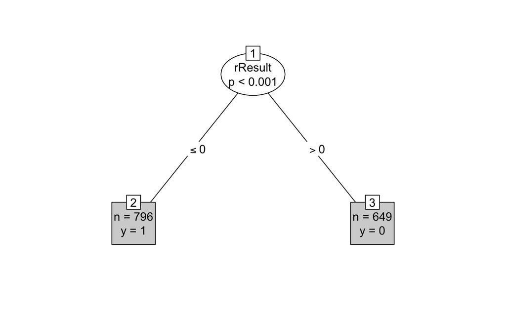

```r
mod1 <- party::ctree (bResult ~ gamelength+rResult, data = LCK)

plot(mod1, type = "simple")
```

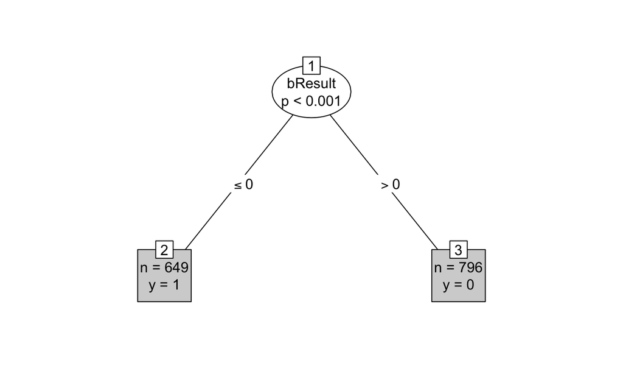

```r
mod2 <- party::ctree (rResult ~ gamelength+bResult, data = LCK)

plot(mod2, type = "simple")
```

```r
NA
NA
```

##### Trying to find out which team wins using ifelse function, But failed.

```r
blueWins = 1
blueLose = 0
blueResult <-
  LCK%>%
  select(bResult)
ifelse ( blueResult == "1",blueWins, blueLose  )
```

```
        bResult
   [1,]       1
   [2,]       0
   [3,]       1
   [4,]       1
   [5,]       0
   [6,]       0
   [7,]       1
   [8,]       1
   [9,]       0
  [10,]       1
  [11,]       0
  [12,]       1
  [13,]       1
  [14,]       0
```

[output cut: 987 more lines]